# Re-analysis of Cao et al. 2025 (GSE207192)

Author

Richard Ahn

## Setup

```r
library(Seurat)
library(Matrix)
library(data.table)

geo_dir  <- "data/raw/geo"
proc_dir <- "data/processed"
dir.create(proc_dir, showWarnings = FALSE, recursive = TRUE)

geo_file <- function(...) file.path(geo_dir, paste0("GSE207192_", ...))

# formatting helpers for numbers quoted inline in the prose
fmt_n <- function(x) format(x, big.mark = ",", scientific = FALSE, trim = TRUE)
fmt_e <- function(x) sprintf("%.1e", x)
```

## Load the processed GEO matrices

GEO provides one RNA matrix and one ADT matrix per stage (pre- and post-infusion), stored as genes × cells in Matrix Market format. Gene names, protein names and cell barcodes are in separate one-column CSVs. Both modalities share a single cell barcode file per stage.

```r
read_names <- function(path) fread(path, header = TRUE)[[1]]

load_stage <- function(stage) {
  rna <- as(readMM(geo_file(stage, "_Infusion_scRNA_Raw_Counts.mtx.gz")), "CsparseMatrix")
  adt <- as(readMM(geo_file(stage, "_Infusion_ADT_Raw_Counts.mtx.gz")), "CsparseMatrix")

  rna_features <- read_names(geo_file(stage, "_Infusion_scRNA_Raw_Counts_features_rownames.csv.gz"))
  adt_features <- read_names(geo_file(stage, "_Infusion_scADT_Raw_Counts_features_rownames.csv.gz"))
  cells        <- read_names(geo_file(stage, "_Infusion_scADT_and_scRNA_Raw_Counts_cells_colnames.csv.gz"))
  meta         <- fread(geo_file(stage, "_Infusion_scADT_and_scRNA_Raw_Counts_metaData.csv.gz"),
                        colClasses = "character")

  # Dimensions must line up with the name files before we attach names
  stopifnot(
    nrow(rna) == length(rna_features), ncol(rna) == length(cells),
    nrow(adt) == length(adt_features), ncol(adt) == length(cells),
    !anyDuplicated(cells)
  )

  dimnames(rna) <- list(make.unique(rna_features), cells)
  dimnames(adt) <- list(adt_features, cells)

  # Metadata must cover exactly the same cells, in the same order
  stopifnot(identical(meta$cells, cells))
  meta <- as.data.frame(meta)
  rownames(meta) <- meta$cells
  meta$cells <- NULL

  obj <- CreateSeuratObject(counts = rna, assay = "RNA", project = paste0(stage, "_Infusion"),
                            meta.data = meta)
  obj[["ADT"]] <- CreateAssay5Object(counts = adt)
  obj$stage <- stage
  obj
}
```

```r
pre  <- load_stage("Pre")
post <- load_stage("Post")
pre
```

```
An object of class Seurat
33571 features across 23663 samples within 2 assays
Active assay: RNA (33539 features, 0 variable features)
 1 layer present: counts
 1 other assay present: ADT
```

```r
post
```

```
An object of class Seurat
33571 features across 55185 samples within 2 assays
Active assay: RNA (33539 features, 0 variable features)
 1 layer present: counts
 1 other assay present: ADT
```

```r
# Duplicated gene symbols in the GEO file (made unique with a .1 suffix on load)
raw_genes <- read_names(geo_file("Pre", "_Infusion_scRNA_Raw_Counts_features_rownames.csv.gz"))
raw_genes[duplicated(raw_genes)]
```

```
character(0)
```

```r
# ADT panel (Seurat swaps any "_" for "-")
rownames(pre[["ADT"]])
```

```
 [1] "CD3E"   "CD5"    "TCRab"  "TCRgd"  "CD4"    "CD8A"   "CD45RO" "CCR7"
 [9] "CD95"   "CD57"   "CD25"   "CD127"  "CD103"  "CAR"    "CXCR3"  "CCR4"
[17] "CCR6"   "PD-1"   "TIM-3"  "LAG-3"  "CD39"   "TIGIT"  "CD27"   "CD40L"
[25] "GITR"   "OX40"   "4-1BB"  "CD28"   "IgG1"   "IgG2a"  "IgG2b"  "CD45RA"
```

```r
# Same 32 proteins in both stages, but in a different order (CD45RA is last in pre, first in post)
setequal(rownames(pre[["ADT"]]), rownames(post[["ADT"]]))
```

```
[1] TRUE
```

```r
identical(rownames(pre[["ADT"]]), rownames(post[["ADT"]]))
```

```
[1] FALSE
```

```r
identical(rownames(pre[["RNA"]]), rownames(post[["RNA"]]))
```

```
[1] TRUE
```

```r
# Cells with no ADT counts at all
sapply(list(pre = pre, post = post), function(o) sum(o$nCount_ADT == 0))
```

```
 pre post
   0   25
```

```r
table(post$orig.ident[post$nCount_ADT == 0])
```

```
028-d04-nonT 031-d10-CART 031-d21-CART 031-d30-CART 033-d10-nonT 033-d21-carT
          25            0            0            0            0            0
033-d28-CART 034-d08-CART 034-d21-CART 039-d10-CART 039-d21-CART 039-d28-CART
           0            0            0            0            0            0
 048-d14-CAR  048-d21-CAR  048-d28-CAR 049-d12-CART 049-d21-CART 049-d28-CART
           0            0            0            0            0            0
049-d90-CART  116-d10-CAR  116-d21-CAR  116-d28-CAR
           0            0            0            0
```

## Metadata

```r
head(pre[[]])
```

```
                        orig.ident nCount_RNA nFeature_RNA patient patientShort
P033_AAACGGGCAAGTAGTA-1       P033       5585         1965     033          P01
P033_AAAGATGAGCGTGAAC-1       P033      13571         3320     033          P01
P033_AAAGATGCAATCAGAA-1       P033      23353         4584     033          P01
P033_AAAGATGTCTGAAAGA-1       P033      10035         2688     033          P01
P033_AAAGCAATCGGCCGAT-1       P033       4252         1705     033          P01
P033_AAAGTAGCAAGTAATG-1       P033      22621         4088     033          P01
                        RNA_celltype ADT_celltype Final_celltype nCount_ADT
P033_AAACGGGCAAGTAGTA-1    doubleNeg          CD4            CD4       2223
P033_AAAGATGAGCGTGAAC-1          CD4          CD4            CD4       2657
P033_AAAGATGCAATCAGAA-1          CD4          CD4            CD4       2732
P033_AAAGATGTCTGAAAGA-1          CD4          CD4            CD4       2141
P033_AAAGCAATCGGCCGAT-1    doubleNeg          CD4            CD4       2249
P033_AAAGTAGCAAGTAATG-1          CD4          CD4            CD4       2085
                        nFeature_ADT stage
P033_AAACGGGCAAGTAGTA-1           31   Pre
P033_AAAGATGAGCGTGAAC-1           31   Pre
P033_AAAGATGCAATCAGAA-1           31   Pre
P033_AAAGATGTCTGAAAGA-1           31   Pre
P033_AAAGCAATCGGCCGAT-1           31   Pre
P033_AAAGTAGCAAGTAATG-1           31   Pre
```

```r
head(post[[]])
```

```
                                  orig.ident nCount_RNA nFeature_RNA patient
028-d04-nonT_AAGGAGCCATCCAACA-1 028-d04-nonT       2408         1014    P034
028-d04-nonT_AGCGTATCATGCGCAC-1 028-d04-nonT      10578         2976    P034
028-d04-nonT_ATAAGAGAGCCACTAT-1 028-d04-nonT       4123         1491    P034
028-d04-nonT_CAGCAGCAGGTAGCTG-1 028-d04-nonT       3049         1161    P034
028-d04-nonT_CGGACACTCGAATGGG-1 028-d04-nonT       6491         2320    P034
028-d04-nonT_CGGACGTCAAGTCTAC-1 028-d04-nonT        886          510    P034
                                patientShort time RNA_celltype ADT_celltype
028-d04-nonT_AAGGAGCCATCCAACA-1          P03  d05    doubleNeg    doubleNeg
028-d04-nonT_AGCGTATCATGCGCAC-1          P03  d05    doublePos    doubleNeg
028-d04-nonT_ATAAGAGAGCCACTAT-1          P03  d05          CD4    doubleNeg
028-d04-nonT_CAGCAGCAGGTAGCTG-1          P03  d05    doubleNeg    doubleNeg
028-d04-nonT_CGGACACTCGAATGGG-1          P03  d05          CD4    doubleNeg
028-d04-nonT_CGGACGTCAAGTCTAC-1          P03  d05    doubleNeg    doubleNeg
                                Final_celltype nCount_ADT nFeature_ADT stage
028-d04-nonT_AAGGAGCCATCCAACA-1      doubleNeg          0            0  Post
028-d04-nonT_AGCGTATCATGCGCAC-1      doubleNeg          0            0  Post
028-d04-nonT_ATAAGAGAGCCACTAT-1   undetermined          0            0  Post
028-d04-nonT_CAGCAGCAGGTAGCTG-1      doubleNeg          0            0  Post
028-d04-nonT_CGGACACTCGAATGGG-1   undetermined          0            0  Post
028-d04-nonT_CGGACGTCAAGTCTAC-1      doubleNeg          0            0  Post
```

```r
table(pre$patientShort, pre$patient)
```

```
       031  033  034  039  048  049  116
  P01    0 3499    0    0    0    0    0
  P02    0    0    0    0    0 3649    0
  P03    0    0 4485    0    0    0    0
  P04 2430    0    0    0    0    0    0
  P05    0    0    0 4427    0    0    0
  P06    0    0    0    0    4    0    0
  P07    0    0    0    0    0    0 5169
```

```r
table(post$patientShort, post$time)
```

```
       d05  d08  d10  d12  d14  d21  d28  d30  d90
  P01    0    0   20    0    0 4066 1205    0    0
  P02    0    0    0 4307    0 2941 6166    0  633
  P03   25  275    0    0    0 2111    0    0    0
  P04    0    0 2627    0    0 4825    0 1765    0
  P05    0    0 1683    0    0 2185 1158    0    0
  P06    0    0    0    0 1572 5722 4726    0    0
  P07    0    0 5614    0    0  920  639    0    0
```

```r
table(pre$Final_celltype)
```

```
         CD4          CD8    doubleNeg    doublePos undetermined
        6818        13658         1135          607         1445
```

```r
table(post$Final_celltype)
```

```
         CD4          CD8    doubleNeg    doublePos undetermined
       11031        40539         1650         1311          654
```

## Cell barcode format

Every barcode should look like `<sample prefix>_<16-nt 10x barcode>-1`.

```r
barcode_re <- "^([^_]+)_([ACGT]{16})-([0-9]+)$"

check_barcodes <- function(obj) {
  bc <- colnames(obj)
  ok <- grepl(barcode_re, bc)
  list(
    n_cells        = length(bc),
    n_bad_format   = sum(!ok),
    gem_suffixes   = table(sub(barcode_re, "\\3", bc[ok])),
    n_dup_core_bc  = sum(duplicated(sub(barcode_re, "\\1_\\2", bc[ok]))),
    prefixes       = table(prefix = sub(barcode_re, "\\1", bc[ok]))
  )
}

check_barcodes(pre)
```

```
$n_cells
[1] 23663

$n_bad_format
[1] 0

$gem_suffixes

    1
23663

$n_dup_core_bc
[1] 0

$prefixes
prefix
 031  039  048  116 P033 P034 P049
2430 4427    4 5169 3499 4485 3649
```

```r
check_barcodes(post)
```

```
$n_cells
[1] 55185

$n_bad_format
[1] 0

$gem_suffixes

    1
55185

$n_dup_core_bc
[1] 0

$prefixes
prefix
028-d04-nonT 031-d10-CART 031-d21-CART 031-d30-CART 033-d10-nonT 033-d21-carT
          25         2627         4825         1765           20         4066
033-d28-CART 034-d08-CART 034-d21-CART 039-d10-CART 039-d21-CART 039-d28-CART
        1205          275         2111         1683         2185         1158
 048-d14-CAR  048-d21-CAR  048-d28-CAR 049-d12-CART 049-d21-CART 049-d28-CART
        1572         5722         4726         4307         2941         6166
049-d90-CART  116-d10-CAR  116-d21-CAR  116-d28-CAR
         633         5614          920          639
```

### Does the barcode prefix agree with the metadata?

Pre-infusion prefixes are the patient ID, but the style varies: `P033`, `P034` and `P049` keep the “P”, while `031`, `039`, `048` and `116` drop it. Post-infusion prefixes follow `<patient>-<day>-<sort label>` (e.g. `031-d10-CART`).

```r
pre_prefix <- sub(barcode_re, "\\1", colnames(pre))
table(prefix = pre_prefix, patient = pre$patient)
```

```
      patient
prefix  031  033  034  039  048  049  116
  031  2430    0    0    0    0    0    0
  039     0    0    0 4427    0    0    0
  048     0    0    0    0    4    0    0
  116     0    0    0    0    0    0 5169
  P033    0 3499    0    0    0    0    0
  P034    0    0 4485    0    0    0    0
  P049    0    0    0    0    0 3649    0
```

```r
post_prefix <- sub(barcode_re, "\\1", colnames(post))
post_parts  <- tstrsplit(post_prefix, "-")
post_check  <- data.frame(
  prefix        = post_prefix,
  prefix_pt     = paste0("P", post_parts[[1]]),
  prefix_day    = post_parts[[2]],
  meta_patient  = post$patient,
  meta_time     = post$time
)
post_check$patient_match <- post_check$prefix_pt  == post_check$meta_patient
post_check$day_match     <- post_check$prefix_day == post_check$meta_time

unique(post_check[!(post_check$patient_match & post_check$day_match),
                  c("prefix", "meta_patient", "meta_time")])
```

```
                                      prefix meta_patient meta_time
028-d04-nonT_AAGGAGCCATCCAACA-1 028-d04-nonT         P034       d05
```

```r
table(mismatch = !(post_check$patient_match & post_check$day_match))
```

```
mismatch
FALSE  TRUE
55160    25
```

### Summary of checks

- **Format:** all 23,663 pre-infusion and 55,185 post-infusion barcodes match `<prefix>_<16-nt barcode>-1`. Every cell has GEM suffix `-1`, and no barcode is duplicated.
- **Metadata:** cell order in the metadata files matches the matrix columns exactly in both stages.
- **Pre-infusion prefixes:** inconsistent style (`P033` vs `031`), but every prefix maps to one patient. The `patient` column has no “P” here (`033`), whereas post-infusion uses `P034`.
- **Pre-infusion P06 (patient 048):** only 4 cells.
- **Post-infusion `028-d04-nonT` (25 cells):** the barcode prefix says patient 028, day 4, but the metadata says P034 at d05. These cells also have zero ADT counts. They are the only mismatch and are probably a small non-T control sample. Flag them before any per-patient analysis.
- **ADT panel:** the same 32 proteins in both stages, in a different order.

## Match TCR data to the count matrices

The TCR tables come from `cellranger vdj aggr` across all 30 libraries (7 pre-infusion and 23 post-infusion). Aggregation drops the sample prefix and appends a library number instead (`AAACCTGAGAAGGTGA-1`, `...-2`, …). 10x reuses the same barcode list in every library, so the 16-nt barcode alone does not identify a cell. We have to work out which suffix belongs to which sample, then join on barcode **plus** suffix.

### Suffix → library map

The contig table records `donor`, `origin` and `Meta:time` for each cell, so the map comes from the data itself.

```r
contigs <- fread(geo_file("All_TCR_Aggregated_filtered_contig_annotations.csv.gz"))
stopifnot(all(grepl("^[ACGT]{16}-[0-9]+$", contigs$barcode)))
contigs[, `:=`(core = sub("-[0-9]+$", "", barcode),
               sfx  = as.integer(sub("^.*-", "", barcode)))]

# All contigs are already filtered: cells, productive, high-confidence
contigs[, .N, by = .(is_cell, productive, high_confidence, `Meta:celltype`)]
```

```
   is_cell productive high_confidence Meta:celltype      N
    <lgcl>     <lgcl>          <lgcl>        <char>  <int>
1:    TRUE       TRUE            TRUE          CART 150378
```

```r
lib_map <- unique(contigs[, .(sfx, donor, time = `Meta:time`, origin)])[order(sfx)]
# Each suffix is one library, and each donor + day is one suffix
stopifnot(!anyDuplicated(lib_map$sfx), !anyDuplicated(lib_map[, .(donor, time)]))
lib_map[, n_tcr_cells := contigs[, uniqueN(barcode), by = sfx][lib_map, on = "sfx", V1]]
lib_map
```

```
      sfx donor   time       origin n_tcr_cells
    <int> <int> <char>       <char>       <int>
 1:     1    31    d10 031-d10-CART        2355
 2:     2    31    d21 031-d21-CART        4286
 3:     3    31    d30 031-d30-CART        1371
 4:     4    33    d10 033-d10-CART          25
 5:     5    33    d21 033-d21-CART        3776
 6:     6    33    d28 033-d28-CART        1092
 7:     7    34    d05 034-d05-CART          22
 8:     8    34    d08 034-d08-CART         271
 9:     9    34    d21 034-d21-CART        2336
10:    10    39    d10 039-d10-CART         947
11:    11    39    d21 039-d21-CART        1902
12:    12    39    d28 039-d28-CART         870
13:    13    48    d14 048-d14-CART        1364
```

[output cut: 19 more lines]

Suffixes 1–23 are the post-infusion timepoints and 24–30 are pre-infusion (`d00`), one per patient.

### Assign each GEX cell its expected suffix

We assign suffixes from the cell metadata (`patient` + `time`, with pre-infusion set to `d00`), not from the barcode prefix. That matters for the 25 `028-d04-nonT` cells, whose prefix disagrees with their metadata (see above).

```r
gex_cells <- function(obj, stage) {
  data.table(
    cell   = colnames(obj),
    stage  = stage,
    prefix = sub(barcode_re, "\\1", colnames(obj)),
    core   = sub(barcode_re, "\\2", colnames(obj)),
    donor  = as.integer(sub("^P", "", obj$patient)),
    time   = if (stage == "Pre") "d00" else obj$time
  )
}
gex <- rbind(gex_cells(pre, "Pre"), gex_cells(post, "Post"))
gex <- lib_map[, .(donor, time, sfx, origin)][gex, on = .(donor, time)]
stopifnot(!anyNA(gex$sfx))

unique(gex[, .(stage, prefix, donor, time, sfx, origin)])[order(sfx)]
```

```
     stage       prefix donor   time   sfx       origin
    <char>       <char> <int> <char> <int>       <char>
 1:   Post 031-d10-CART    31    d10     1 031-d10-CART
 2:   Post 031-d21-CART    31    d21     2 031-d21-CART
 3:   Post 031-d30-CART    31    d30     3 031-d30-CART
 4:   Post 033-d10-nonT    33    d10     4 033-d10-CART
 5:   Post 033-d21-carT    33    d21     5 033-d21-CART
 6:   Post 033-d28-CART    33    d28     6 033-d28-CART
 7:   Post 028-d04-nonT    34    d05     7 034-d05-CART
 8:   Post 034-d08-CART    34    d08     8 034-d08-CART
 9:   Post 034-d21-CART    34    d21     9 034-d21-CART
10:   Post 039-d10-CART    39    d10    10 039-d10-CART
11:   Post 039-d21-CART    39    d21    11 039-d21-CART
12:   Post 039-d28-CART    39    d28    12 039-d28-CART
13:   Post  048-d14-CAR    48    d14    13 048-d14-CART
```

[output cut: 18 more lines]

### Check the map against the barcodes themselves

This check doesn’t use the metadata. For each GEX sample, we find the TCR suffix where its 16-nt barcodes most often appear. If the map is right, that suffix should be the one assigned above.

```r
tcr_core <- unique(contigs[, .(core, sfx)])
hits <- merge(gex[, .(prefix, core)], tcr_core, by = "core", allow.cartesian = TRUE)

top_hit <- hits[, .N, by = .(prefix, hit_sfx = sfx)
              ][, share := N / sum(N), by = prefix
              ][order(-N)][, .SD[1], by = prefix]

crosscheck <- unique(gex[, .(prefix, sfx, origin)])[top_hit, on = "prefix"]
crosscheck[, agrees := sfx == hit_sfx]
crosscheck[order(sfx), .(prefix, origin, expected_sfx = sfx, top_hit_sfx = hit_sfx,
                         share_on_top = round(share, 3), agrees)]
```

```
          prefix       origin expected_sfx top_hit_sfx share_on_top agrees
          <char>       <char>        <int>       <int>        <num> <lgcl>
 1: 031-d10-CART 031-d10-CART            1           1        0.916   TRUE
 2: 031-d21-CART 031-d21-CART            2           2        0.906   TRUE
 3: 031-d30-CART 031-d30-CART            3           3        0.884   TRUE
 4: 033-d10-nonT 033-d10-CART            4           4        0.923   TRUE
 5: 033-d21-carT 033-d21-CART            5           5        0.909   TRUE
 6: 033-d28-CART 033-d28-CART            6           6        0.890   TRUE
 7: 028-d04-nonT 034-d05-CART            7           7        0.783   TRUE
 8: 034-d08-CART 034-d08-CART            8           8        0.909   TRUE
 9: 034-d21-CART 034-d21-CART            9           9        0.914   TRUE
10: 039-d10-CART 039-d10-CART           10          10        0.857   TRUE
11: 039-d21-CART 039-d21-CART           11          11        0.902   TRUE
12: 039-d28-CART 039-d28-CART           12          12        0.897   TRUE
13:  048-d14-CAR 048-d14-CART           13          13        0.895   TRUE
```

[output cut: 18 more lines]

```r
stopifnot(all(crosscheck$agrees))
```

Every sample’s top hit is its expected suffix, typically with ~90% of hits. The rest are chance barcode collisions with other libraries. This is why a join on the 16-nt barcode alone would be wrong:

```r
cores_per_lib <- tcr_core[, .(n_libs = .N), by = core]
gex[cores_per_lib, n_libs_with_core := i.n_libs, on = "core"]
gex[is.na(n_libs_with_core), n_libs_with_core := 0L]
gex[, tcr_barcode := paste0(core, "-", sfx)]
gex[, has_tcr := tcr_barcode %in% contigs$barcode]

gex[, .(
  gex_cells               = .N,
  naive_match_core_only   = sum(n_libs_with_core > 0),
  core_in_multiple_libs   = sum(n_libs_with_core > 1),
  naive_false_matches     = sum(n_libs_with_core > 0 & !has_tcr),
  correct_match           = sum(has_tcr)
), by = stage]
```

```
    stage gex_cells naive_match_core_only core_in_multiple_libs
   <char>     <int>                 <int>                 <int>
1:    Pre     23663                 21595                  1937
2:   Post     55185                 48059                  4225
   naive_false_matches correct_match
                 <int>         <int>
1:                 203         21392
2:                 723         47336
```

### Join and report match rates

Collapse contigs to one row per cell before joining.

```r
stopifnot(contigs[, uniqueN(raw_clonotype_id), by = barcode][, all(V1 == 1)])
tcr_cells <- contigs[, .(
  tcr_clonotype = raw_clonotype_id[1],
  tcr_n_TRA     = sum(chain == "TRA"),
  tcr_n_TRB     = sum(chain == "TRB"),
  tcr_TRA_cdr3  = paste(cdr3[chain == "TRA"], collapse = ";"),
  tcr_TRB_cdr3  = paste(cdr3[chain == "TRB"], collapse = ";")
), by = .(tcr_barcode = barcode)]
```

**Share of GEX cells with a TCR**, by sample:

```r
by_sample <- gex[, .(gex_cells = .N, with_tcr = sum(has_tcr),
                     pct = round(100 * mean(has_tcr), 1)), by = .(stage, origin, sfx)][order(sfx)]
by_sample
```

```
     stage       origin   sfx gex_cells with_tcr   pct
    <char>       <char> <int>     <int>    <int> <num>
 1:   Post 031-d10-CART     1      2627     2322  88.4
 2:   Post 031-d21-CART     2      4825     4277  88.6
 3:   Post 031-d30-CART     3      1765     1354  76.7
 4:   Post 033-d10-CART     4        20       12  60.0
 5:   Post 033-d21-CART     5      4066     3716  91.4
 6:   Post 033-d28-CART     6      1205     1073  89.0
 7:   Post 034-d05-CART     7        25       18  72.0
 8:   Post 034-d08-CART     8       275      230  83.6
 9:   Post 034-d21-CART     9      2111     2000  94.7
10:   Post 039-d10-CART    10      1683      938  55.7
11:   Post 039-d21-CART    11      2185     1882  86.1
12:   Post 039-d28-CART    12      1158      863  74.5
13:   Post 048-d14-CART    13      1572     1316  83.7
```

[output cut: 18 more lines]

```r
gex[, .(gex_cells = .N, with_tcr = sum(has_tcr), pct = round(100 * mean(has_tcr), 1)), by = stage]
```

```
    stage gex_cells with_tcr   pct
   <char>     <int>    <int> <num>
1:    Pre     23663    21392  90.4
2:   Post     55185    47336  85.8
```

```r
gex[, .(gex_cells = .N, with_tcr = sum(has_tcr), pct = round(100 * mean(has_tcr), 1))]
```

```
   gex_cells with_tcr   pct
       <int>    <int> <num>
1:     78848    68728  87.2
```

**Share of TCR cells found in the count matrices**, by library. TCR cells without a GEX match were probably removed by the authors’ GEX quality filtering.

```r
tcr_cells[, in_gex := tcr_barcode %in% gex$tcr_barcode]
tcr_cells[, sfx := as.integer(sub("^.*-", "", tcr_barcode))]
tcr_side <- tcr_cells[, .(tcr_cells = .N, in_gex = sum(in_gex),
                          pct = round(100 * mean(in_gex), 1)), by = sfx
                    ][lib_map[, .(sfx, origin)], on = "sfx"][order(sfx)]
tcr_side
```

```
      sfx tcr_cells in_gex   pct       origin
    <int>     <int>  <int> <num>       <char>
 1:     1      2355   2322  98.6 031-d10-CART
 2:     2      4286   4277  99.8 031-d21-CART
 3:     3      1371   1354  98.8 031-d30-CART
 4:     4        25     12  48.0 033-d10-CART
 5:     5      3776   3716  98.4 033-d21-CART
 6:     6      1092   1073  98.3 033-d28-CART
 7:     7        22     18  81.8 034-d05-CART
 8:     8       271    230  84.9 034-d08-CART
 9:     9      2336   2000  85.6 034-d21-CART
10:    10       947    938  99.0 039-d10-CART
11:    11      1902   1882  98.9 039-d21-CART
12:    12       870    863  99.2 039-d28-CART
13:    13      1364   1316  96.5 048-d14-CART
```

[output cut: 19 more lines]

```r
tcr_cells[, .(tcr_cells = .N, in_gex = sum(in_gex), pct = round(100 * mean(in_gex), 1))]
```

```
   tcr_cells in_gex   pct
       <int>  <int> <num>
1:     73250  68728  93.8
```

### Attach TCR data to the Seurat objects

```r
add_tcr <- function(obj) {
  m <- tcr_cells[gex[match(colnames(obj), cell), .(cell, tcr_barcode, tcr_library = origin)],
                 on = "tcr_barcode"]
  stopifnot(identical(m$cell, colnames(obj)))
  m <- as.data.frame(m[, .(tcr_barcode, tcr_library, has_tcr = !is.na(tcr_clonotype),
                           tcr_clonotype, tcr_n_TRA, tcr_n_TRB, tcr_TRA_cdr3, tcr_TRB_cdr3)])
  rownames(m) <- colnames(obj)
  AddMetaData(obj, m)
}
pre  <- add_tcr(pre)
post <- add_tcr(post)

table(pre$has_tcr)
```

```
FALSE  TRUE
 2271 21392
```

```r
table(post$has_tcr)
```

```
FALSE  TRUE
 7849 47336
```

```r
rm(contigs, tcr_core, hits, top_hit, crosscheck, cores_per_lib, tcr_cells, gex, gex_cells,
   lib_map, by_sample, tcr_side, add_tcr, post_check, post_parts, post_prefix, pre_prefix,
   raw_genes, check_barcodes)
invisible(gc())
```

### TCR matching summary

- **Mapping:** the 30 aggregation suffixes map one-to-one to libraries (1–23 post-infusion, 24–30 pre-infusion). The barcode-overlap check agrees with the metadata for every GEX sample.
- **`028-d04-nonT`:** its barcodes land on suffix 7 (`034-d05-CART`). That confirms the metadata (P034, d05) is right and the barcode prefix is wrong.
- **Match rate:** 68,728 of 78,848 GEX cells (87.2%) have a TCR: pre-infusion 90.4% (21,392 / 23,663) and post-infusion 85.8% (47,336 / 55,185). In the other direction, 93.8% of TCR cells (68,728 / 73,250) are found in the count matrices.
- **Joining on barcode alone would be wrong:** it would add 926 false matches (203 pre, 723 post), where a cell’s barcode exists only in another sample’s TCR library.
- **Low-match libraries:** `116-d21` (14.3%; only 147 TCR cells for 920 GEX cells), `039-d10` (55.7%) and `116-d28` (58.8%). In the first two, almost all TCR cells are in the GEX data, so the TCR library itself captured fewer cells. This isn’t a joining problem. `049-d05-CART` (suffix 16, 2 cells) has no GEX counterpart.

### Save TCR-annotated objects (before QC)

```r
saveRDS(pre,  file.path(proc_dir, "seurat_pre_infusion.rds"))
saveRDS(post, file.path(proc_dir, "seurat_post_infusion.rds"))
```

## Quality control

The GEO matrices are already filtered by the authors. Post-infusion cells all have >500 UMIs and <10% mitochondrial reads. Pre-infusion has no cell below 683 UMIs but allows up to 25% mito. The two stages also differ a lot in depth: the median is ~13k UMIs per cell pre-infusion vs ~4k post-infusion. So QC here is a light second pass:

- **Low UMIs / low genes:** more than 3 MADs below the sample’s median, on a log scale. The cutoff is computed per sample because depth varies so much between samples. Samples with <100 cells are pooled within their stage.
- **High mito:** a fixed 10% cap in both stages, matching the authors’ post-infusion filter. Per-sample 3-MAD mito cutoffs land at ~4.5–9.7% and would remove ~3,300 cells. That is stricter than the authors and penalises activated T cells, which naturally carry more mitochondrial RNA.
- **No ADT counts:** cells with no surface-protein data at all. These are the 25 `028-d04-nonT` cells.
- **Doublets:** scDblFinder, run per sample (samples with ≥100 cells only).

### QC metrics

```r
library(scater)
library(patchwork)
library(scDblFinder)

add_qc <- function(obj) {
  obj[["percent.mt"]]   <- PercentageFeatureSet(obj, pattern = "^MT-",       assay = "RNA")
  obj[["percent.ribo"]] <- PercentageFeatureSet(obj, pattern = "^RP[SL][0-9]", assay = "RNA")
  iso <- c("IgG1", "IgG2a", "IgG2b")
  adt <- LayerData(obj, assay = "ADT", layer = "counts")
  obj$adt_isotype_counts <- colSums(adt[iso, , drop = FALSE])
  obj$adt_isotype_frac   <- obj$adt_isotype_counts / pmax(obj$nCount_ADT, 1)
  obj
}
pre  <- add_qc(pre)
post <- add_qc(post)

qc_cols <- c("nCount_RNA", "nFeature_RNA", "percent.mt", "percent.ribo",
             "nCount_ADT", "nFeature_ADT", "adt_isotype_frac")
qc_summary <- function(obj) t(sapply(obj[[]][, qc_cols], function(x)
  round(quantile(x, c(0, 0.01, 0.05, 0.5, 0.95, 0.99, 1)), 2)))
cat("== PRE\n");  print(qc_summary(pre))
```

```
== PRE
```

```
                    0%      1%      5%      50%      95%      99%     100%
nCount_RNA       683.0 1395.00 3601.00 13112.00 40238.90 59740.28 98685.00
nFeature_RNA     474.0  766.00 1491.00  3314.00  5763.90  6648.76  8223.00
percent.mt         0.0    0.82    1.33     3.71     8.86    14.51    24.64
percent.ribo       0.4    4.81   12.73    20.07    28.35    32.59    41.50
nCount_ADT        88.0  439.00  831.00  3280.00  7621.90 11877.98 77035.00
nFeature_ADT      11.0   24.00   27.00    31.00    32.00    32.00    32.00
adt_isotype_frac   0.0    0.00    0.00     0.01     0.05     0.07     0.11
```

```r
cat("== POST\n"); print(qc_summary(post))
```

```
== POST
```

```
                    0%     1%      5%     50%     95%      99%     100%
nCount_RNA       501.0 926.68 1801.20 4035.00 9238.00 14478.08 36788.00
nFeature_RNA     128.0 618.00  962.00 1661.00 2862.80  3751.00  5968.00
percent.mt         0.0   1.11    1.51    2.78    5.61     8.56     9.99
percent.ribo       0.1   5.05   12.20   19.97   29.62    35.62    46.63
nCount_ADT         0.0 125.00  253.00 1430.00 5182.00  8984.16 26526.00
nFeature_ADT       0.0  12.00   16.00   26.00   30.00    30.00    31.00
adt_isotype_frac   0.0   0.00    0.00    0.00    0.03     0.05     0.53
```

```r
per_sample <- function(o) {
  d <- data.table(sample = o$orig.ident, n_umi = as.numeric(o$nCount_RNA),
                  n_gene = as.numeric(o$nFeature_RNA), mt = o$percent.mt,
                  adt = as.numeric(o$nCount_ADT), celltype = o$Final_celltype)
  d[, .(cells = .N, med_umi = median(n_umi), med_gene = median(n_gene),
        med_mt = round(median(mt), 2), p99_mt = round(quantile(mt, .99), 1),
        med_adt = median(adt), pct_undet = round(100 * mean(celltype == "undetermined"), 1)),
    by = sample][order(sample)]
}
cat("== PRE\n");  print(per_sample(pre))
```

```
== PRE
```

```
   sample cells med_umi med_gene med_mt p99_mt med_adt pct_undet
   <fctr> <int>   <num>    <num>  <num>  <num>   <num>     <num>
1:    031  2430 12402.0   3338.5   2.21   11.5    3886       1.2
2:    039  4427 16621.0   3976.0   2.71   13.0    4111       1.2
3:    048     4 12418.5   3162.0   2.98   12.4    2181      25.0
4:    116  5169  9842.0   2723.0   2.16   11.5    1697      25.5
5:   P033  3499 12795.0   3277.0   4.37   17.9    3392       0.3
6:   P034  4485 14114.0   3356.0   5.41   12.6    4038       0.3
7:   P049  3649 13571.0   3358.0   4.89   19.0    2965       0.5
```

```r
cat("== POST\n"); print(per_sample(post))
```

```
== POST
```

```
          sample cells med_umi med_gene med_mt p99_mt med_adt pct_undet
          <fctr> <int>   <num>    <num>  <num>  <num>   <num>     <num>
 1: 028-d04-nonT    25  4368.0   1542.0   2.59    5.4     0.0      44.0
 2: 031-d10-CART  2627  4197.0   1726.0   3.02    9.0   486.0       1.0
 3: 031-d21-CART  4825  3336.0   1491.0   2.92    8.5   832.0       2.1
 4: 031-d30-CART  1765  3261.0   1438.0   3.30    9.6   822.0       3.1
 5: 033-d10-nonT    20  3022.0   1159.5   1.84    3.7  1749.0      10.0
 6: 033-d21-carT  4066  4705.5   2005.0   2.39    8.5  1706.0       0.1
 7: 033-d28-CART  1205  2877.0   1373.0   2.64    7.7  3042.0       0.0
 8: 034-d08-CART   275 10369.0   2968.0   4.73    9.7  5140.0       1.5
 9: 034-d21-CART  2111  5693.0   2203.0   3.75    9.2  1274.0       0.5
10: 039-d10-CART  1683  3292.0   1479.0   3.03    9.7   341.0       2.6
11: 039-d21-CART  2185  3103.0   1361.0   2.69    8.1   448.0       3.5
12: 039-d28-CART  1158  3702.0   1560.0   2.64    8.5   403.5       7.4
13:  048-d14-CAR  1572  4970.0   1941.0   2.35    6.9  4526.0       0.4
14:  048-d21-CAR  5722  4075.5   1643.0   2.39    7.7  2171.0       0.9
15:  048-d28-CAR  4726  3962.0   1587.0   2.31    6.7  2353.0       0.6
16: 049-d12-CART  4307  5034.0   2061.0   2.87    7.8  1614.0       0.3
17: 049-d21-CART  2941  4545.0   1845.0   3.40    9.1  1355.0       0.8
18: 049-d28-CART  6166  2505.0   1263.0   3.35    7.7   471.5       1.3
19: 049-d90-CART   633  4338.0   1742.0   3.16    6.4  5839.0       0.0
20:  116-d10-CAR  5614  5111.5   1837.0   2.56    7.2  2416.0       0.5
21:  116-d21-CAR   920  4992.5   1876.0   2.48    5.5  2633.5       0.4
22:  116-d28-CAR   639  6448.0   2076.0   2.41    7.2  5351.0       0.2
          sample cells med_umi med_gene med_mt p99_mt med_adt pct_undet
          <fctr> <int>   <num>    <num>  <num>  <num>   <num>     <num>
```

In pre-infusion, the “P”-prefixed samples (P033, P034, P049) have about twice the median mito % of the others (~4.4–5.4% vs ~2.2%). Together with the different naming, this suggests two processing batches. Pre-infusion patient 116 has 25.5% “undetermined” cells, vs ≤1.2% in the other pre-infusion samples (excluding the 4-cell 048 sample).

### QC flags

```r
max_mt <- 10

qc_flag <- function(obj, min_cells = 100) {
  md  <- obj[[]]
  n   <- table(md$orig.ident)
  # Tiny samples borrow thresholds from the pooled small samples of the stage
  grp <- ifelse(n[as.character(md$orig.ident)] < min_cells, "small_pooled",
                as.character(md$orig.ident))
  low_umi  <- isOutlier(md$nCount_RNA,   nmads = 3, log = TRUE, type = "lower", batch = grp)
  low_gene <- isOutlier(md$nFeature_RNA, nmads = 3, log = TRUE, type = "lower", batch = grp)
  obj$qc_group    <- grp
  obj$qc_low_umi  <- as.logical(low_umi)
  obj$qc_low_gene <- as.logical(low_gene)
  obj$qc_high_mt  <- obj$percent.mt > max_mt
  obj$qc_no_adt   <- obj$nCount_ADT == 0
  thr <- data.table(group    = names(attr(low_umi, "thresholds")["lower", ]),
                    min_umi  = round(attr(low_umi,  "thresholds")["lower", ]),
                    min_gene = round(attr(low_gene, "thresholds")["lower", ]),
                    max_mt   = max_mt)
  list(obj = obj, thresholds = thr)
}

res <- qc_flag(pre);  pre  <- res$obj; thr_pre  <- res$thresholds
res <- qc_flag(post); post <- res$obj; thr_post <- res$thresholds
rm(res); invisible(gc())

flag_cols <- c("qc_low_umi", "qc_low_gene", "qc_high_mt", "qc_no_adt")
flag_summary <- function(o) {
  d <- as.data.table(o[[]][, c("orig.ident", flag_cols)])
  d[, any_flag := qc_low_umi | qc_low_gene | qc_high_mt | qc_no_adt]
  d[, c(.(cells = .N), lapply(.SD, sum), .(pct_flagged = round(100 * mean(any_flag), 1))),
    by = orig.ident, .SDcols = c(flag_cols, "any_flag")][order(orig.ident)]
}
cat("== PRE thresholds\n");  print(thr_pre)
```

```
== PRE thresholds
```

```
          group min_umi min_gene max_mt
         <char>   <num>    <num>  <num>
1:          031    3180     1467     10
2:          039    1977     1347     10
3:          116     939      673     10
4:         P033    2047     1123     10
5:         P034    3103     1391     10
6:         P049    2058     1144     10
7: small_pooled    4267     2028     10
```

```r
cat("== PRE flags\n");       print(flag_summary(pre))
```

```
== PRE flags
```

```
   orig.ident cells qc_low_umi qc_low_gene qc_high_mt qc_no_adt any_flag
       <fctr> <int>      <int>       <int>      <int>     <int>    <int>
1:        031  2430         40          36         40         0       70
2:        039  4427         22          48        140         0      173
3:        048     4          0           0          1         0        1
4:        116  5169         44         133        104         0      227
5:       P033  3499         15          26        211         0      225
6:       P034  4485         24          27         73         0       90
7:       P049  3649         11          16        232         0      239
   pct_flagged
         <num>
1:         2.9
2:         3.9
3:        25.0
4:         4.4
5:         6.4
6:         2.0
7:         6.5
```

```r
cat("== POST thresholds\n"); print(thr_post)
```

```
== POST thresholds
```

```
           group min_umi min_gene max_mt
          <char>   <num>    <num>  <num>
 1: 031-d10-CART    1772      914     10
 2: 031-d21-CART    1586      865     10
 3: 031-d30-CART    1272      716     10
 4: 033-d21-carT    2343     1223     10
 5: 033-d28-CART    1505      833     10
 6: 034-d08-CART    1260      894     10
 7: 034-d21-CART    2570     1292     10
 8: 039-d10-CART     768      588     10
 9: 039-d21-CART    1139      707     10
10: 039-d28-CART    1268      733     10
11:  048-d14-CAR    1532      831     10
12:  048-d21-CAR    1814      900     10
13:  048-d28-CAR    1785      882     10
14: 049-d12-CART    1979     1085     10
15: 049-d21-CART    1737      923     10
16: 049-d28-CART    1155      692     10
17: 049-d90-CART    1846      986     10
18:  116-d10-CAR    1579      827     10
19:  116-d21-CAR     950      690     10
20:  116-d28-CAR    1191      708     10
21: small_pooled    1138      471     10
           group min_umi min_gene max_mt
          <char>   <num>    <num>  <num>
```

```r
cat("== POST flags\n");      print(flag_summary(post))
```

```
== POST flags
```

```
      orig.ident cells qc_low_umi qc_low_gene qc_high_mt qc_no_adt any_flag
          <fctr> <int>      <int>       <int>      <int>     <int>    <int>
 1: 028-d04-nonT    25          1           0          0        25       25
 2: 031-d10-CART  2627        114          83          0         0      122
 3: 031-d21-CART  4825        176         146          0         0      180
 4: 031-d30-CART  1765         82          64          0         0       84
 5: 033-d10-nonT    20          0           0          0         0        0
 6: 033-d21-carT  4066        302         298          0         0      313
 7: 033-d28-CART  1205         36          35          0         0       39
 8: 034-d08-CART   275         24          34          0         0       34
 9: 034-d21-CART  2111        105          98          0         0      114
10: 039-d10-CART  1683         27          23          0         0       28
11: 039-d21-CART  2185         47          38          0         0       54
12: 039-d28-CART  1158         31          24          0         0       32
13:  048-d14-CAR  1572         33          30          0         0       33
```

[output cut: 37 more lines]

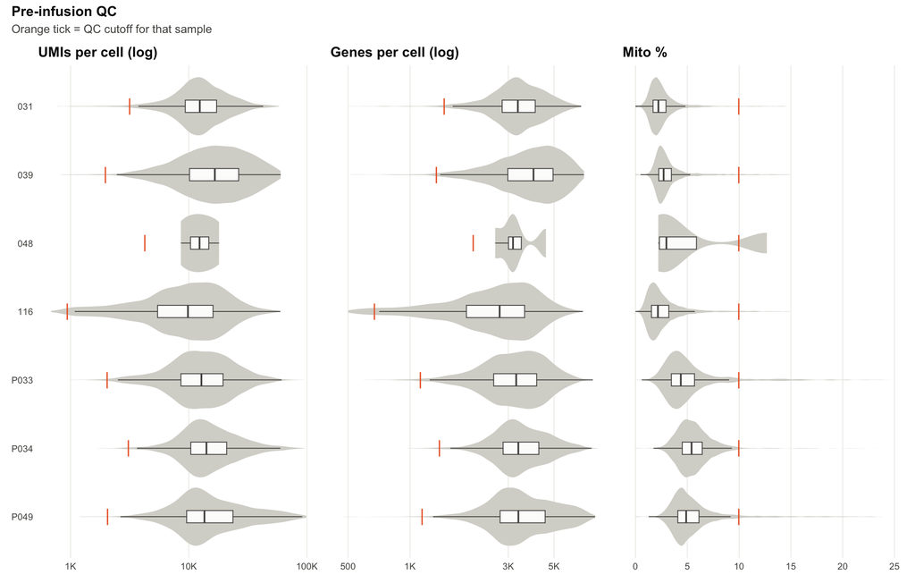

```r
qc_theme <- theme_minimal(base_size = 10) +
  theme(panel.grid.major.y = element_blank(), panel.grid.minor = element_blank(),
        panel.grid.major.x = element_line(colour = "#ebeae6", linewidth = 0.3),
        plot.title = element_text(face = "bold", colour = "#0b0b0b"),
        plot.subtitle = element_text(colour = "#52514e"),
        axis.text = element_text(colour = "#52514e"))

qc_panel <- function(md, cut, col, cut_col, label, log = TRUE) {
  p <- ggplot(md, aes(x = .data[[col]], y = sample)) +
    geom_violin(fill = "#d6d5d0", colour = NA, scale = "width", width = 0.85) +
    geom_boxplot(width = 0.18, outlier.shape = NA, fill = "#fcfcfb",
                 colour = "#52514e", linewidth = 0.35) +
    geom_point(data = cut, aes(x = .data[[cut_col]]), shape = "|", size = 5, colour = "#eb6834") +
    scale_y_discrete(limits = rev) + labs(title = label, x = NULL, y = NULL) + qc_theme
  if (log) p + scale_x_log10(labels = scales::label_number(scale_cut = scales::cut_short_scale()))
  else p
}

qc_plot <- function(obj, thr, title) {
  md  <- as.data.table(obj[[]])[, .(sample = orig.ident, qc_group,
                                    umi = as.numeric(nCount_RNA), gene = as.numeric(nFeature_RNA),
                                    mt = percent.mt)]
  cut <- unique(md[, .(sample, qc_group)])[thr, on = c(qc_group = "group"), nomatch = 0]
  (qc_panel(md, cut, "umi", "min_umi", "UMIs per cell (log)") |
   qc_panel(md, cut, "gene", "min_gene", "Genes per cell (log)") + theme(axis.text.y = element_blank()) |
   qc_panel(md, cut, "mt", "max_mt", "Mito %", log = FALSE) + theme(axis.text.y = element_blank())) +
    plot_annotation(title = title, subtitle = "Orange tick = QC cutoff for that sample",
                    theme = qc_theme)
}

qc_plot(pre,  thr_pre,  "Pre-infusion QC")
```

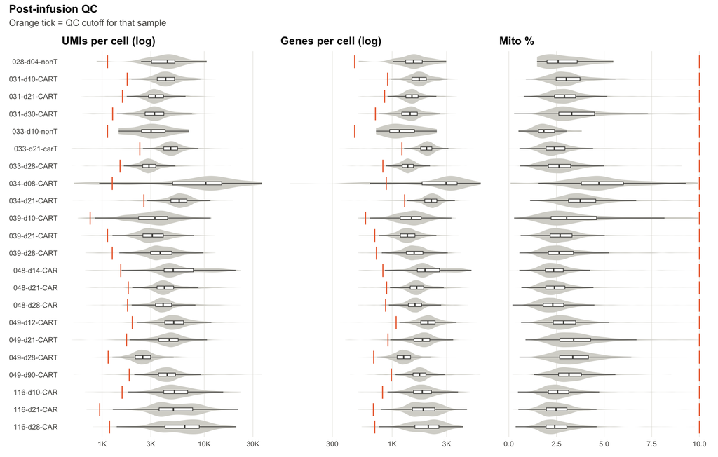

```r
qc_plot(post, thr_post, "Post-infusion QC")
```

### Doublets

```r
run_dbl <- function(obj, min_cells = 100) {
  n    <- table(obj$orig.ident)
  keep <- as.character(obj$orig.ident) %in% names(n)[n >= min_cells]
  sce  <- SingleCellExperiment(list(counts = LayerData(obj, assay = "RNA", layer = "counts")[, keep]))
  set.seed(1)
  sce  <- scDblFinder(sce, samples = as.character(obj$orig.ident[keep]),
                      BPPARAM = BiocParallel::SerialParam())
  obj$dbl_class <- "not_run"
  obj$dbl_score <- NA_real_
  obj$dbl_class[keep] <- as.character(sce$scDblFinder.class)
  obj$dbl_score[keep] <- sce$scDblFinder.score
  rm(sce); invisible(gc())
  obj
}
pre  <- run_dbl(pre)
post <- run_dbl(post)

dbl_summary <- function(o) {
  d <- as.data.table(o[[]])[, .(sample = orig.ident, dbl_class, multi_TRB = tcr_n_TRB >= 2)]
  d[, .(cells = .N, doublets = sum(dbl_class == "doublet"),
        pct_dbl = round(100 * mean(dbl_class == "doublet"), 1),
        not_run = sum(dbl_class == "not_run")), by = sample][order(sample)]
}
cat("== PRE\n");  print(dbl_summary(pre))
```

```
== PRE
```

```
   sample cells doublets pct_dbl not_run
   <fctr> <int>    <int>   <num>   <int>
1:    031  2430      120     4.9       0
2:    039  4427      287     6.5       0
3:    048     4        0     0.0       4
4:    116  5169      431     8.3       0
5:   P033  3499      212     6.1       0
6:   P034  4485      290     6.5       0
7:   P049  3649      226     6.2       0
```

```r
cat("== POST\n"); print(dbl_summary(post))
```

```
== POST
```

```
          sample cells doublets pct_dbl not_run
          <fctr> <int>    <int>   <num>   <int>
 1: 028-d04-nonT    25        0     0.0      25
 2: 031-d10-CART  2627      115     4.4       0
 3: 031-d21-CART  4825      214     4.4       0
 4: 031-d30-CART  1765       80     4.5       0
 5: 033-d10-nonT    20        0     0.0      20
 6: 033-d21-carT  4066      160     3.9       0
 7: 033-d28-CART  1205       28     2.3       0
 8: 034-d08-CART   275       23     8.4       0
 9: 034-d21-CART  2111       55     2.6       0
10: 039-d10-CART  1683       75     4.5       0
11: 039-d21-CART  2185       69     3.2       0
12: 039-d28-CART  1158       41     3.5       0
13:  048-d14-CAR  1572       74     4.7       0
14:  048-d21-CAR  5722      386     6.7       0
15:  048-d28-CAR  4726      234     5.0       0
16: 049-d12-CART  4307      210     4.9       0
17: 049-d21-CART  2941      132     4.5       0
18: 049-d28-CART  6166      386     6.3       0
19: 049-d90-CART   633       12     1.9       0
20:  116-d10-CAR  5614      334     5.9       0
21:  116-d21-CAR   920       31     3.4       0
22:  116-d28-CAR   639       17     2.7       0
          sample cells doublets pct_dbl not_run
          <fctr> <int>    <int>   <num>   <int>
```

scDblFinder calls 2–9% of cells doublets per sample. As a check that doesn’t depend on the expression data, cells with two or more TCR beta chains, a common sign of a doublet, should be called doublets much more often:

```r
dbl_vs_trb <- function(o) {
  d <- as.data.table(o[[]])[has_tcr == TRUE & dbl_class != "not_run",
                            .(multi_TRB = tcr_n_TRB >= 2, doublet = dbl_class == "doublet")]
  d[, .(cells = .N, pct_doublet = round(100 * mean(doublet), 1)), by = multi_TRB][order(multi_TRB)]
}
cat("== PRE\n");  print(dbl_vs_trb(pre))
```

```
== PRE
```

```
   multi_TRB cells pct_doublet
      <lgcl> <int>       <num>
1:     FALSE 20568         3.7
2:      TRUE   820        46.1
```

```r
cat("== POST\n"); print(dbl_vs_trb(post))
```

```
== POST
```

```
   multi_TRB cells pct_doublet
      <lgcl> <int>       <num>
1:     FALSE 45440         2.4
2:      TRUE  1866        49.6
```

### Filter

```r
set_qc_pass <- function(o) {
  o$qc_pass <- !(o$qc_low_umi | o$qc_low_gene | o$qc_high_mt | o$qc_no_adt) &
    o$dbl_class != "doublet"
  o
}
pre  <- set_qc_pass(pre)
post <- set_qc_pass(post)

pass_summary <- function(o) {
  d <- as.data.table(o[[]])
  out <- d[, .(cells = .N, kept = sum(qc_pass), removed = sum(!qc_pass),
               pct_kept = round(100 * mean(qc_pass), 1)), by = orig.ident][order(orig.ident)]
  rbind(out, d[, .(orig.ident = "TOTAL", cells = .N, kept = sum(qc_pass), removed = sum(!qc_pass),
                   pct_kept = round(100 * mean(qc_pass), 1))])
}
cat("== PRE\n");  print(pass_summary(pre))
```

```
== PRE
```

```
   orig.ident cells  kept removed pct_kept
       <fctr> <int> <int>   <int>    <num>
1:        031  2430  2241     189     92.2
2:        039  4427  3968     459     89.6
3:        048     4     3       1     75.0
4:        116  5169  4512     657     87.3
5:       P033  3499  3063     436     87.5
6:       P034  4485  4105     380     91.5
7:       P049  3649  3184     465     87.3
8:      TOTAL 23663 21076    2587     89.1
```

```r
cat("== POST\n"); print(pass_summary(post))
```

```
== POST
```

```
      orig.ident cells  kept removed pct_kept
          <fctr> <int> <int>   <int>    <num>
 1: 028-d04-nonT    25     0      25      0.0
 2: 031-d10-CART  2627  2390     237     91.0
 3: 031-d21-CART  4825  4431     394     91.8
 4: 031-d30-CART  1765  1601     164     90.7
 5: 033-d10-nonT    20    20       0    100.0
 6: 033-d21-carT  4066  3593     473     88.4
 7: 033-d28-CART  1205  1138      67     94.4
 8: 034-d08-CART   275   218      57     79.3
 9: 034-d21-CART  2111  1942     169     92.0
10: 039-d10-CART  1683  1580     103     93.9
11: 039-d21-CART  2185  2062     123     94.4
12: 039-d28-CART  1158  1085      73     93.7
13:  048-d14-CAR  1572  1465     107     93.2
14:  048-d21-CAR  5722  5098     624     89.1
15:  048-d28-CAR  4726  4313     413     91.3
16: 049-d12-CART  4307  3993     314     92.7
17: 049-d21-CART  2941  2686     255     91.3
18: 049-d28-CART  6166  5628     538     91.3
19: 049-d90-CART   633   596      37     94.2
20:  116-d10-CAR  5614  5180     434     92.3
21:  116-d21-CAR   920   877      43     95.3
22:  116-d28-CAR   639   615      24     96.2
23:        TOTAL 55185 50511    4674     91.5
      orig.ident cells  kept removed pct_kept
          <fctr> <int> <int>   <int>    <num>
```

Save every cell’s QC flags before dropping any, so the filtering decisions stay on record:

```r
flag_export <- c("orig.ident", "stage", "nCount_RNA", "nFeature_RNA", "percent.mt", "percent.ribo",
                 "nCount_ADT", "qc_group", "qc_low_umi", "qc_low_gene", "qc_high_mt", "qc_no_adt",
                 "dbl_class", "dbl_score", "qc_pass")
qc_flags <- rbind(data.table(cell = colnames(pre),  pre[[]][, flag_export]),
                  data.table(cell = colnames(post), post[[]][, flag_export]))
fwrite(qc_flags, file.path(proc_dir, "qc_flags.csv.gz"))
rm(qc_flags, flag_export); invisible(gc())
```

```r
pre  <- subset(pre,  cells = colnames(pre)[pre$qc_pass])
post <- subset(post, cells = colnames(post)[post$qc_pass])
invisible(gc())
c(pre = ncol(pre), post = ncol(post))
```

```
  pre  post
21076 50511
```

## Normalize

RNA uses LogNormalize (scale factor 10,000). SCTransform was ruled out to keep memory use manageable on a 16 GB machine. ADT uses CLR across each cell’s proteins (`margin = 2`), the standard Seurat method for antibody counts.

```r
normalize <- function(o) {
  o <- NormalizeData(o, assay = "RNA", normalization.method = "LogNormalize",
                     scale.factor = 1e4, verbose = FALSE)
  o <- NormalizeData(o, assay = "ADT", normalization.method = "CLR", margin = 2, verbose = FALSE)
  o
}
pre  <- normalize(pre)
post <- normalize(post)
invisible(gc())
```

```r
rm(add_qc, qc_cols, qc_summary, per_sample, qc_flag, flag_cols, flag_summary, thr_pre, thr_post,
   max_mt, qc_theme, qc_panel, qc_plot, run_dbl, dbl_summary, dbl_vs_trb, set_qc_pass,
   pass_summary, normalize)
invisible(gc())
```

## VDJ QC

The TCR columns attached earlier used every contig. Here they’re rebuilt from contigs that pass contig-level QC:

- **Contig flags:** `productive`, `full_length`, `high_confidence` and `is_cell` all TRUE.
- **UMI support:** at least 2 UMIs per contig (3 for a noisy run; see the check below).
- **Chain counts:** up to 2 TRA is normal (weak allelic exclusion). A cell with more than 1 TRB, or more than 2 TRA, is flagged as a likely doublet (`tcr_multichain`). Its chains are kept, and each cell’s top-UMI TRA and TRB are stored separately (`tcr_TRA1_*`, `tcr_TRB1_*`).
- **Barcode matching:** only cells that passed GEX QC are kept (`pre` and `post` are already filtered).

```r
contigs <- fread(geo_file("All_TCR_Aggregated_filtered_contig_annotations.csv.gz"),
                 select = c("barcode", "is_cell", "contig_id", "high_confidence", "full_length",
                            "productive", "chain", "cdr3", "cdr3_nt", "v_gene", "j_gene",
                            "reads", "umis", "raw_clonotype_id", "origin"))
cat("contigs:", nrow(contigs), " cells:", uniqueN(contigs$barcode), "\n")
```

```
contigs: 150378  cells: 73250
```

```r
contigs[, .N, by = .(is_cell, productive, full_length, high_confidence)]
```

```
   is_cell productive full_length high_confidence      N
    <lgcl>     <lgcl>      <lgcl>          <lgcl>  <int>
1:    TRUE       TRUE        TRUE            TRUE 150378
```

```r
contigs[, .N, by = chain]
```

```
    chain     N
   <char> <int>
1:    TRB 75107
2:    TRA 75271
```

```r
quantile(contigs$umis, c(0, .01, .05, .1, .25, .5, .75, .9, .99, 1))
```

```
  0%   1%   5%  10%  25%  50%  75%  90%  99% 100%
   1    1    2    3    5    9   16   26   57  259
```

```r
contigs[, .(n = .N, umi1 = round(100 * mean(umis == 1), 1), umi2 = round(100 * mean(umis == 2), 1),
            umi3plus = round(100 * mean(umis >= 3), 1)), by = chain]
```

```
    chain     n  umi1  umi2 umi3plus
   <char> <int> <num> <num>    <num>
1:    TRB 75107   0.7   2.0     97.3
2:    TRA 75271   4.8   9.3     85.9
```

GEO provides only Cell Ranger’s *filtered* contig file, so every contig already passes the four flags. UMI support is the filter that matters. Only 0.7% of TRB contigs have a single UMI, but 4.8% of TRA contigs have 1 UMI and 9.3% have 2.

### Is this a noisy run? (2 vs 3 UMIs)

Ambient contigs, mostly from highly expanded clones, usually show up as an *extra* chain in a cell (not its top-UMI chain of that type) whose CDR3 belongs to an expanded clone in the same library. If 2-UMI contigs show that pattern much like 1-UMI contigs, the 3-UMI cutoff is warranted.

```r
contigs[, umi_rank := frank(-umis, ties.method = "first"), by = .(barcode, chain)]
contigs[, extra_chain := umi_rank > 1]

# Expanded CDR3s: seen as the top chain in >= 10 cells of the same library
top_cdr3 <- contigs[umi_rank == 1, .(n_cells = uniqueN(barcode)), by = .(origin, chain, cdr3_nt)]
expanded <- top_cdr3[n_cells >= 10, .(origin, chain, cdr3_nt)]
contigs[, from_expanded := FALSE]
contigs[expanded, from_expanded := TRUE, on = .(origin, chain, cdr3_nt)]

contigs[, umi_bin := fcase(umis == 1, "1", umis == 2, "2", umis == 3, "3", umis <= 5, "4-5", default = "6+")]
amb <- contigs[, .(contigs = .N,
                   pct_extra_chain        = round(100 * mean(extra_chain), 1),
                   pct_expanded_cdr3      = round(100 * mean(from_expanded), 1),
                   pct_extra_and_expanded = round(100 * mean(extra_chain & from_expanded), 1)),
               by = .(chain, umi_bin)][order(chain, umi_bin)]
amb
```

```
     chain umi_bin contigs pct_extra_chain pct_expanded_cdr3
    <char>  <char>   <int>           <num>             <num>
 1:    TRA       1    3604             9.8               9.9
 2:    TRA       2    7024            18.6              10.5
 3:    TRA       3    8274            17.5              10.1
 4:    TRA     4-5   15589            14.3               9.8
 5:    TRA      6+   40780             7.4              11.5
 6:    TRB       1     514            15.2               9.1
 7:    TRB       2    1527             9.6               9.4
 8:    TRB       3    2433             8.5              10.2
 9:    TRB     4-5    5796             7.7              10.4
10:    TRB      6+   64837             3.1              12.0
    pct_extra_and_expanded
                     <num>
 1:                    1.4
 2:                    2.3
 3:                    1.6
 4:                    1.1
 5:                    0.2
 6:                    0.8
 7:                    0.5
 8:                    0.5
 9:                    0.3
10:                    0.2
```

```r
rm(top_cdr3, expanded); invisible(gc())
```

It isn’t noisy. Extra chains from expanded clones are ≤2.3% of contigs in every UMI bin, and 2-UMI contigs aren’t meaningfully worse than 3-UMI ones (TRA 2.3% vs 1.6%; TRB 0.5% vs 0.5%). So we use the standard 2-UMI cutoff. Most low-UMI contigs are the cell’s *only* chain of that type, so the filter mainly costs some cells their TRA rather than removing ambient chains.

### Filter contigs and rebuild per-cell TCR columns

```r
min_umi <- 2
n_before <- nrow(contigs)
vdj <- contigs[is_cell & productive & full_length & high_confidence & umis >= min_umi]
cat("contigs kept:", nrow(vdj), "of", n_before, sprintf("(%.1f%%)", 100 * nrow(vdj) / n_before), "\n")
```

```
contigs kept: 146260 of 150378 (97.3%)
```

```r
contigs[umis < min_umi, .N, by = chain]
```

```
    chain     N
   <char> <int>
1:    TRA  3604
2:    TRB   514
```

```r
rm(contigs); invisible(gc())
```

```r
setorder(vdj, barcode, chain, -umis)
vdj_cells <- vdj[, .(
  tcr_n_TRA      = sum(chain == "TRA"),
  tcr_n_TRB      = sum(chain == "TRB"),
  tcr_TRA_cdr3   = paste(cdr3[chain == "TRA"], collapse = ";"),   # ordered by UMI, high to low
  tcr_TRB_cdr3   = paste(cdr3[chain == "TRB"], collapse = ";"),
  tcr_TRA_umis   = paste(umis[chain == "TRA"], collapse = ";"),
  tcr_TRB_umis   = paste(umis[chain == "TRB"], collapse = ";"),
  tcr_TRA1_nt    = cdr3_nt[chain == "TRA"][1],                    # top-UMI chain of each type
  tcr_TRB1_nt    = cdr3_nt[chain == "TRB"][1],
  tcr_TRA1_v     = v_gene[chain == "TRA"][1],
  tcr_TRB1_v     = v_gene[chain == "TRB"][1],
  tcr_clonotype_cr = raw_clonotype_id[1]
), by = .(tcr_barcode = barcode)]
vdj_cells[tcr_TRA_cdr3 == "", `:=`(tcr_TRA_cdr3 = NA, tcr_TRA_umis = NA)]
vdj_cells[tcr_TRB_cdr3 == "", `:=`(tcr_TRB_cdr3 = NA, tcr_TRB_umis = NA)]
vdj_cells[, tcr_multichain := tcr_n_TRB > 1 | tcr_n_TRA > 2]
rm(vdj); invisible(gc())

vdj_cells[, .N, by = .(tcr_n_TRA, tcr_n_TRB)][order(-N)]
```

```
   tcr_n_TRA tcr_n_TRB     N
       <int>     <int> <int>
1:         1         1 52621
2:         0         1  9421
3:         2         1  6869
4:         1         2  1614
5:         1         0  1446
6:         2         2  1105
7:         0         2   122
8:         2         0    19
```

`tcr_clonotype_cr` is Cell Ranger’s clonotype, which was built from the *unfiltered* chains. For clonotype analyses after this filter, prefer a key built from the kept chains (e.g. donor + `tcr_TRB1_nt` + `tcr_TRA1_nt`).

### Attach to GEX-QC cells

```r
old_tcr_cols <- c("has_tcr", "tcr_clonotype", "tcr_n_TRA", "tcr_n_TRB", "tcr_TRA_cdr3", "tcr_TRB_cdr3")
attach_vdj <- function(obj) {
  for (col in intersect(old_tcr_cols, colnames(obj[[]]))) obj[[col]] <- NULL
  m <- vdj_cells[data.table(tcr_barcode = obj$tcr_barcode), on = "tcr_barcode"]
  stopifnot(identical(m$tcr_barcode, unname(obj$tcr_barcode)))
  m[, `:=`(tcr_has_TRB = !is.na(tcr_n_TRB) & tcr_n_TRB >= 1,
           tcr_paired  = !is.na(tcr_n_TRB) & tcr_n_TRB >= 1 & tcr_n_TRA >= 1)]
  m[is.na(tcr_multichain), tcr_multichain := FALSE]
  m <- as.data.frame(m[, !"tcr_barcode"])
  rownames(m) <- colnames(obj)
  AddMetaData(obj, m)
}
pre  <- attach_vdj(pre)
post <- attach_vdj(post)
vdj_in_gex <- vdj_cells[, mean(tcr_barcode %in% c(pre$tcr_barcode, post$tcr_barcode))]
cat(sprintf("VDJ cells kept after GEX QC: %.1f%%\n", 100 * vdj_in_gex))
```

```
VDJ cells kept after GEX QC: 87.8%
```

```r
rm(attach_vdj, old_tcr_cols, vdj_in_gex); invisible(gc())
```

### Recovery

Recovery is the share of GEX-QC cells with a productive TRB, and the share with a paired TRA + TRB.

```r
recovery <- function(o, by) {
  d <- as.data.table(o[[]])
  d[, .(cells = .N,
        pct_TRB        = round(100 * mean(tcr_has_TRB), 1),
        pct_paired     = round(100 * mean(tcr_paired), 1),
        pct_multichain = round(100 * mean(tcr_multichain), 1)), by = by][order(get(by[1]))]
}
cat("== Overall\n");       print(rbind(recovery(pre, "stage"), recovery(post, "stage")))
```

```
== Overall
```

```
    stage cells pct_TRB pct_paired pct_multichain
   <char> <int>   <num>      <num>          <num>
1:    Pre 21076    91.9       86.0            2.0
2:   Post 50511    86.9       74.9            1.8
```

```r
cat("== PRE by sample\n");  print(recovery(pre, "orig.ident"))
```

```
== PRE by sample
```

```
   orig.ident cells pct_TRB pct_paired pct_multichain
       <fctr> <int>   <num>      <num>          <num>
1:        031  2241    95.3       89.7            1.8
2:        039  3968    83.7       80.3            3.6
3:        048     3   100.0       66.7            0.0
4:        116  4512    87.3       78.3            1.5
5:       P033  3063    95.6       90.5            1.1
6:       P034  4105    97.9       91.1            1.9
7:       P049  3184    94.9       90.8            2.2
```

```r
cat("== POST by sample\n"); print(recovery(post, "orig.ident"))
```

```
== POST by sample
```

```
      orig.ident cells pct_TRB pct_paired pct_multichain
          <fctr> <int>   <num>      <num>          <num>
 1: 031-d10-CART  2390    90.0       72.7            3.1
 2: 031-d21-CART  4431    91.3       78.9            1.5
 3: 031-d30-CART  1601    80.4       61.3            1.2
 4: 033-d10-nonT    20    55.0       10.0            0.0
 5: 033-d21-carT  3593    96.5       89.0            1.3
 6: 033-d28-CART  1138    86.6       57.0            0.8
 7: 034-d08-CART   218    89.9       79.4            1.4
 8: 034-d21-CART  1942    95.9       90.7            1.6
 9: 039-d10-CART  1580    53.2       17.8            0.3
10: 039-d21-CART  2062    86.4       72.6            1.3
11: 039-d28-CART  1085    74.9       62.0            1.0
12:  048-d14-CAR  1465    84.9       77.6            1.7
13:  048-d21-CAR  5098    89.3       81.8            1.9
14:  048-d28-CAR  4313    89.6       79.1            1.9
15: 049-d12-CART  3993    95.2       88.3            3.1
16: 049-d21-CART  2686    94.2       87.7            2.6
17: 049-d28-CART  5628    90.0       70.9            2.3
18: 049-d90-CART   596    93.6       79.5            1.3
19:  116-d10-CAR  5180    84.1       74.9            1.5
20:  116-d21-CAR   877    14.5       12.4            0.1
21:  116-d28-CAR   615    58.5       52.7            0.8
      orig.ident cells pct_TRB pct_paired pct_multichain
          <fctr> <int>   <num>      <num>          <num>
```

```r
cat("== By cell type\n")
```

```
== By cell type
```

```r
print(rbind(recovery(pre, c("stage", "Final_celltype")), recovery(post, c("stage", "Final_celltype"))))
```

```
     stage Final_celltype cells pct_TRB pct_paired pct_multichain
    <char>         <char> <int>   <num>      <num>          <num>
 1:    Pre            CD4  5975    96.5       90.7            1.9
 2:    Pre      doublePos   329    91.8       87.5            6.7
 3:    Pre   undetermined  1314    84.2       74.2            1.3
 4:    Pre            CD8 12473    95.6       90.0            2.2
 5:    Pre      doubleNeg   985    27.5       21.9            0.5
 6:   Post            CD8 37027    93.5       80.8            1.9
 7:   Post            CD4 10629    78.9       67.9            1.6
 8:   Post      doubleNeg  1423    14.8        9.9            0.3
 9:   Post   undetermined   540    27.8       20.9            1.5
10:   Post      doublePos   892    60.2       50.9            3.7
```

“doubleNeg” cells mostly lack a TRB (15–28%). They’re probably γδ T cells or non-T cells, not αβ T cells, so αβ recovery is reported for CD4 + CD8 cells only:

```r
ab <- function(o) {
  d <- as.data.table(o[[]])[Final_celltype %in% c("CD4", "CD8")]
  d[, .(cells = .N, pct_TRB = round(100 * mean(tcr_has_TRB), 1),
        pct_paired = round(100 * mean(tcr_paired), 1),
        pct_multichain = round(100 * mean(tcr_multichain), 1)), by = stage]
}
rbind(ab(pre), ab(post))
```

```
    stage cells pct_TRB pct_paired pct_multichain
   <char> <int>   <num>      <num>          <num>
1:    Pre 18448    95.9       90.3            2.1
2:   Post 47656    90.2       77.9            1.8
```

```r
fwrite(vdj_cells, file.path(proc_dir, "vdj_cells_qc.csv.gz"))
rm(vdj_cells, recovery, ab, min_umi, n_before, amb); invisible(gc())
```

### Caveat: what TCR overlap can and can’t tell us

**Warning**

**These products are autologous, and the GEO post-infusion data is (almost) all CAR+ cells.**

- **Autologous:** the CAR-T product is made from the patient’s own T cells, so the patient’s unengineered T cells can carry the same TCRs as product cells. TCR sequence alone can’t separate product-derived cells from the patient’s own cells.
- **Study design:** after infusion, cells were stained with BV421 anti-CD3ε (SK7) and AF647 CD19 tetramers. They were then sorted into CAR T cells (CD3+ CAR+) and endogenous T cells (CD3+ CAR−), each run as a separate 10x library (Methods). So the study *did* capture unengineered T cells after infusion.
- **What’s in the GEO processed data:** 20 of 22 post-infusion libraries are labelled as CAR T (`-CART`, `-CAR`, `-carT`). Only two tiny libraries are labelled `nonT`: `028-d04-nonT` (25 cells, removed in QC) and `033-d10-nonT` (20 cells). These are plausibly CD3+CAR− sorts, but that is unconfirmed, and the TCR table labels both as `-CART`. In practice, the processed post-infusion data is CAR+ cells only. The endogenous libraries may be in the raw SRA data.
- **What follows:** within this data, pre → post clonotype overlap measures how product clones persist and expand. It doesn’t identify *which* post-infusion cells came from the product, because essentially all of them did. A post-infusion clone with no pre-infusion match is not evidence of an endogenous origin; it more likely reflects how deeply the product was sampled. An endogenous comparator would need the CD3+CAR− libraries from the raw data.
- **Contrast with allogeneic products:** there, donor and host repertoires barely overlap, so TCR overlap alone identifies product cells. That reasoning doesn’t carry over to this dataset.

### The CAR and CD3 ADT signals are missing after infusion

Sorted CAR+ cells should show *more* CAR ADT signal, not less. Instead, CAR is almost absent after infusion, and so is CD3E.

First, check that the post-infusion ADT labels are correct. Each protein should correlate best with its own gene:

```r
adt_rna_pairs <- c(CD4 = "CD4", CD8A = "CD8A", CD5 = "CD5", CD25 = "IL2RA", `PD-1` = "PDCD1",
                   CD27 = "CD27", CD28 = "CD28", TIGIT = "TIGIT", CD39 = "ENTPD1", CD95 = "FAS",
                   CXCR3 = "CXCR3", CCR4 = "CCR4", `4-1BB` = "TNFRSF9")
adt_label_check <- function(o, n = 8000) {
  set.seed(1); cells <- sample(colnames(o), min(n, ncol(o)))
  adt <- as.matrix(LayerData(o, assay = "ADT", layer = "data")[, cells])
  rna <- as.matrix(LayerData(o, assay = "RNA", layer = "data")[adt_rna_pairs, cells])
  cm  <- cor(t(adt), t(rna), method = "spearman"); cm[is.na(cm)] <- 0
  data.table(gene = adt_rna_pairs, expected_adt = names(adt_rna_pairs),
             r_expected = round(cm[cbind(names(adt_rna_pairs), adt_rna_pairs)], 2),
             best_adt = rownames(cm)[apply(cm, 2, which.max)])
}
cat("== PRE\n");  print(adt_label_check(pre))
```

```
== PRE
```

```
       gene expected_adt r_expected best_adt
     <char>       <char>      <num>   <char>
 1:     CD4          CD4       0.64      CD4
 2:    CD8A         CD8A       0.74     CD8A
 3:     CD5          CD5       0.28      CD5
 4:   IL2RA         CD25       0.57     CD25
 5:   PDCD1         PD-1       0.22     PD-1
 6:    CD27         CD27       0.65     CD27
 7:    CD28         CD28       0.35     CD28
 8:   TIGIT        TIGIT       0.49    TIGIT
 9:  ENTPD1         CD39       0.49     CD39
10:     FAS         CD95       0.16   CD45RO
11:   CXCR3        CXCR3       0.18     CD8A
12:    CCR4         CCR4       0.40     CCR4
13: TNFRSF9        4-1BB       0.29    4-1BB
```

```r
cat("== POST\n"); print(adt_label_check(post))
```

```
== POST
```

```
       gene expected_adt r_expected best_adt
     <char>       <char>      <num>   <char>
 1:     CD4          CD4       0.50      CD4
 2:    CD8A         CD8A       0.65     CD8A
 3:     CD5          CD5       0.33      CD5
 4:   IL2RA         CD25       0.22     CD25
 5:   PDCD1         PD-1       0.27     PD-1
 6:    CD27         CD27       0.49     CD27
 7:    CD28         CD28       0.28     CD28
 8:   TIGIT        TIGIT       0.34    TIGIT
 9:  ENTPD1         CD39       0.28     CD39
10:     FAS         CD95       0.18     CD95
11:   CXCR3        CXCR3       0.18    CXCR3
12:    CCR4         CCR4       0.19     CCR4
13: TNFRSF9        4-1BB       0.25    4-1BB
```

```r
rm(adt_rna_pairs, adt_label_check); invisible(gc())
```

Next, compare CAR and CD3E with the isotype controls. An antibody in the staining mix always leaves some background counts, so a reagent far *below* the isotype controls was most likely not in the staining mix, not read out, or completely blocked.

```r
adt_presence <- function(o) {
  m <- LayerData(o, assay = "ADT", layer = "counts")[c("CD3E", "CAR", "IgG1", "IgG2a", "IgG2b"), ]
  d <- data.table(sample = o$orig.ident, t(as.matrix(m > 0)))
  d[, lapply(.SD, function(x) round(100 * mean(x), 1)), by = sample][order(sample)]
}
cat("== PRE: % of cells with any counts\n");  print(adt_presence(pre))
```

```
== PRE: % of cells with any counts
```

```
   sample  CD3E   CAR  IgG1 IgG2a IgG2b
   <fctr> <num> <num> <num> <num> <num>
1:    031   100   0.3  91.5  89.5  66.8
2:    039   100   1.3  96.1  92.4  84.0
3:    048   100   0.0 100.0 100.0 100.0
4:    116   100   2.3 100.0 100.0  99.6
5:   P033   100  99.9 100.0 100.0  99.9
6:   P034   100  99.6 100.0 100.0  99.7
7:   P049   100  69.0 100.0 100.0 100.0
```

```r
cat("== POST: % of cells with any counts\n"); print(adt_presence(post))
```

```
== POST: % of cells with any counts
```

```
          sample  CD3E   CAR  IgG1 IgG2a IgG2b
          <fctr> <num> <num> <num> <num> <num>
 1: 031-d10-CART   0.3   0.0  65.6  89.2  45.4
 2: 031-d21-CART   0.7   0.1  92.8  94.2  83.3
 3: 031-d30-CART   0.9   0.1  57.2  76.1  36.8
 4: 033-d10-nonT   0.0   0.0 100.0  90.0  85.0
 5: 033-d21-carT   0.9   0.1  68.1  58.8  38.8
 6: 033-d28-CART   0.8   0.2  62.4  82.5  58.6
 7: 034-d08-CART   0.9   0.0 100.0  89.4  73.9
 8: 034-d21-CART   0.4   0.0  67.7  38.1  22.9
 9: 039-d10-CART   0.1   0.1  51.0  69.9  34.4
10: 039-d21-CART   0.4   0.0  54.0  75.9  36.0
11: 039-d28-CART   0.7   0.1  54.6  77.2  36.5
12:  048-d14-CAR   1.8   1.3  98.2  97.7  89.0
13:  048-d21-CAR   1.1   0.3  93.4  86.3  67.2
14:  048-d28-CAR   1.3   0.4  94.9  90.3  70.8
15: 049-d12-CART   0.6   0.2  74.8  81.7  50.0
16: 049-d21-CART   0.4   0.1  74.9  83.2  49.0
17: 049-d28-CART   0.2   0.0  32.5  34.6  13.5
18: 049-d90-CART   1.5   0.7  94.8  91.4  79.4
19:  116-d10-CAR   0.7   0.5  98.0  96.8  81.8
20:  116-d21-CAR   2.1   0.8  98.5  99.1  93.0
21:  116-d28-CAR   2.0   2.6  99.0  99.7  96.3
          sample  CD3E   CAR  IgG1 IgG2a IgG2b
          <fctr> <num> <num> <num> <num> <num>
```

```r
rm(adt_presence); invisible(gc())
```

The Methods (CITE-seq antibody preparation) explain most of this:

- **CD3E wasn’t stained after infusion.** The panel has 31 TotalSeq-C reagents: 28 antibodies plus 3 isotype controls. Residual infusion product was stained with all 31. Patient PBMCs (post-infusion) were stained with 30: anti-CD3ε (UCHT1) was *left out*, because those cells were stained with BV421 anti-CD3ε (SK7) for sorting. The residual CD3E counts after infusion are background.
- **“CAR” isn’t one of the 31 documented reagents.** The GEO matrix has 32 ADT features, so “CAR” is an extra, undocumented feature. Its signal appears only in the pre-infusion P-prefixed batch. What it measures is unknown (possibly a DNA-barcoded CD19 reagent used in some samples only, but that’s a guess), so treat it as unusable unless the authors clarify. The CD19 tetramer used for sorting is listed as AF647-labelled, not oligo-barcoded.

**Consequences:**

- **Post-infusion CAR+ status** can’t be checked at the protein level. The RNA does measure the CAR transgene, though (`YESCAR`, see *CAR transgene RNA* below).
- **Drop from the post-infusion ADT assay:** CAR and CD3E, then re-run CLR (below).
- **Before infusion:** CAR is kept in the assay but shouldn’t be used. It’s undocumented, and present only in P033/P034/P049. Don’t compare it across stages or batches.
- **A third sign of two pre-infusion batches:** the CAR feature, alongside the naming and mito differences.

### Drop CAR and CD3E from the post-infusion ADT assay

CLR scales each cell by the geometric mean across its proteins, so the two unmeasured features are removed before normalizing again. `nCount_ADT` and `nFeature_ADT` are recomputed to match.

```r
adt_drop_post <- c("CAR", "CD3E")
post[["ADT"]] <- subset(post[["ADT"]], features = setdiff(rownames(post[["ADT"]]), adt_drop_post))
adt_counts <- LayerData(post, assay = "ADT", layer = "counts")
post$nCount_ADT   <- colSums(adt_counts)
post$nFeature_ADT <- colSums(adt_counts > 0)
rm(adt_counts)
post <- NormalizeData(post, assay = "ADT", normalization.method = "CLR", margin = 2, verbose = FALSE)
DefaultAssay(post) <- "RNA"

stopifnot(nrow(post[["ADT"]]) == 30, !any(adt_drop_post %in% rownames(post[["ADT"]])),
          identical(rownames(LayerData(post, assay = "ADT", layer = "data")),
                    rownames(LayerData(post, assay = "ADT", layer = "counts"))))
rm(adt_drop_post); invisible(gc())
```

- **“nonT” samples:** two post-infusion samples are named “nonT” (`033-d10-nonT`, 20 cells, kept; `028-d04-nonT`, removed in QC). Their sort gate may differ, so consider excluding them from clonotype analyses.

## Remove non-T contamination

In the first variable-gene pass, monocyte genes (S100A8/9/12, LYZ, CST3, C1QA) and platelet genes (PPBP, PF4, GP9) topped the post-infusion list. Sorted CD3+ cells shouldn’t express them, so the cells carrying them are measured and removed here.

### Monocyte-like cells

```r
myeloid_genes <- c("LYZ", "S100A8", "S100A9", "CST3", "FCN1", "CD14")
tcell_genes   <- c("CD3E", "CD3D", "CD3G", "TRAC", "TRBC1", "TRBC2", "CD2")
max_myeloid_pct <- 0.2

flag_myeloid <- function(o) {
  cnt <- LayerData(o, assay = "RNA", layer = "counts")
  o$myeloid_pct <- 100 * colSums(cnt[myeloid_genes, ]) / o$nCount_RNA
  o$tcell_pct   <- 100 * colSums(cnt[tcell_genes, ])   / o$nCount_RNA
  o$qc_myeloid  <- o$myeloid_pct > max_myeloid_pct
  o
}
pre  <- flag_myeloid(pre)
post <- flag_myeloid(post)

myeloid_summary <- function(o) {
  d <- as.data.table(o[[]])
  d[, .(cells = .N, myeloid_flagged = sum(qc_myeloid), pct = round(100 * mean(qc_myeloid), 1),
        flagged_med_tcell_pct = round(median(tcell_pct[qc_myeloid]), 2),
        flagged_pct_TRB = round(100 * mean(tcr_has_TRB[qc_myeloid]), 1)), by = orig.ident][order(orig.ident)]
}
cat("== PRE\n");  print(myeloid_summary(pre))
```

```
== PRE
```

```
   orig.ident cells myeloid_flagged   pct flagged_med_tcell_pct flagged_pct_TRB
       <fctr> <int>           <int> <num>                 <num>           <num>
1:        031  2241               0   0.0                    NA             NaN
2:        039  3968               0   0.0                    NA             NaN
3:        048     3               0   0.0                    NA             NaN
4:        116  4512              12   0.3                  0.00            16.7
5:       P033  3063               0   0.0                    NA             NaN
6:       P034  4105               0   0.0                    NA             NaN
7:       P049  3184               2   0.1                  0.68           100.0
```

```r
cat("== POST\n"); print(myeloid_summary(post))
```

```
== POST
```

```
      orig.ident cells myeloid_flagged   pct flagged_med_tcell_pct
          <fctr> <int>           <int> <num>                 <num>
 1: 031-d10-CART  2390              31   1.3                  0.00
 2: 031-d21-CART  4431             163   3.7                  0.00
 3: 031-d30-CART  1601              94   5.9                  0.00
 4: 033-d10-nonT    20               0   0.0                    NA
 5: 033-d21-carT  3593               0   0.0                    NA
 6: 033-d28-CART  1138               0   0.0                    NA
 7: 034-d08-CART   218               0   0.0                    NA
 8: 034-d21-CART  1942               0   0.0                    NA
 9: 039-d10-CART  1580              49   3.1                  0.00
10: 039-d21-CART  2062             134   6.5                  0.00
11: 039-d28-CART  1085             134  12.4                  0.00
12:  048-d14-CAR  1465             399  27.2                  0.12
13:  048-d21-CAR  5098             492   9.7                  0.00
```

[output cut: 35 more lines]

Cells above 0.2% monocyte UMIs have a median of **zero** T-cell gene expression (CD3, TRAC, TRBC, CD2). Only 12–15% have a TCR, so they are monocytes that got past the sort, not T cells. Many carry the authors’ “CD4” label, since monocytes express CD4 protein. They’re concentrated in patients 116 (12–53% of cells), 048 (9–28%), 039 and 031. Patients 033, 034 and 049 have none. This explains the low TCR recovery in `116-d21` and `116-d28`. In patient 048, 20–56% of flagged cells do have a TCR, so many are probably T-cell/monocyte doublets; they’re removed either way.

### Platelet-bound cells

```r
platelet_genes <- c("PPBP", "PF4", "GP9", "TUBB1", "NRGN", "RGS18", "PTCRA", "CMTM5")
min_platelet_umi <- 5
flag_platelet <- function(o) {
  o$platelet_umi <- colSums(LayerData(o, assay = "RNA", layer = "counts")[platelet_genes, ])
  o$qc_platelet  <- o$platelet_umi >= min_platelet_umi
  o
}
pre  <- flag_platelet(pre)
post <- flag_platelet(post)
rbind(pre = table(pre$qc_platelet), post = table(post$qc_platelet))
```

```
     FALSE TRUE
pre  21071    5
post 49937  574
```

```r
qc_flags <- fread(file.path(proc_dir, "qc_flags.csv.gz"))
contam <- rbind(
  data.table(cell = colnames(pre),  myeloid_pct = pre$myeloid_pct,  qc_myeloid = pre$qc_myeloid,
             platelet_umi = pre$platelet_umi,  qc_platelet = pre$qc_platelet),
  data.table(cell = colnames(post), myeloid_pct = post$myeloid_pct, qc_myeloid = post$qc_myeloid,
             platelet_umi = post$platelet_umi, qc_platelet = post$qc_platelet))
qc_flags <- contam[qc_flags, on = "cell"]
qc_flags[, qc_pass := qc_pass & !fcoalesce(qc_myeloid, FALSE) & !fcoalesce(qc_platelet, FALSE)]
fwrite(qc_flags, file.path(proc_dir, "qc_flags.csv.gz"))
rm(qc_flags, contam)

pre  <- subset(pre,  cells = colnames(pre)[!pre$qc_myeloid & !pre$qc_platelet])
post <- subset(post, cells = colnames(post)[!post$qc_myeloid & !post$qc_platelet])
rm(flag_myeloid, myeloid_summary, myeloid_genes, tcell_genes, max_myeloid_pct,
   flag_platelet, platelet_genes, min_platelet_umi); invisible(gc())
c(pre = ncol(pre), post = ncol(post))
```

```
  pre  post
21057 47074
```

### CAR transgene RNA (`YESCAR`)

The RNA matrix has 33,539 features: the 33,538 genes of 10x’s GRCh38 v3.0.0 reference, plus `YESCAR` as the last feature. This is presumably the axi-cel (Yescarta) CAR transgene, added to the reference. Unlike the ADT data, it gives a direct CAR measurement.

```r
car_rna <- function(o) {
  x <- LayerData(o, assay = "RNA", layer = "counts")["YESCAR", ]
  d <- data.table(sample = o$orig.ident, car = x)
  rbind(d[, .(cells = .N, pct_pos = round(100 * mean(car > 0), 1), median = median(car),
              p90 = as.numeric(quantile(car, .9))), by = sample][order(sample)],
        d[, .(sample = "TOTAL", cells = .N, pct_pos = round(100 * mean(car > 0), 1), median = median(car),
              p90 = as.numeric(quantile(car, .9)))])
}
match("YESCAR", rownames(pre))
```

```
[1] 33539
```

```r
cat("== PRE\n");  print(car_rna(pre))
```

```
== PRE
```

```
   sample cells pct_pos median   p90
   <fctr> <int>   <num>  <num> <num>
1:    031  2238    44.9      0    11
2:    039  3967    39.5      0     9
3:    048     3     0.0      0     0
4:    116  4500    42.1      0    12
5:   P033  3063    48.7      0    14
6:   P034  4105    64.1      3    32
7:   P049  3181    48.9      0    20
8:  TOTAL 21057    48.2      0    16
```

```r
cat("== POST\n"); print(car_rna(post))
```

```
== POST
```

```
          sample cells pct_pos median   p90
          <fctr> <int>   <num>  <num> <num>
 1: 031-d10-CART  2326    51.7      1   3.0
 2: 031-d21-CART  4255    52.9      1   3.0
 3: 031-d30-CART  1463    41.8      0   2.0
 4: 033-d10-nonT    20     0.0      0   0.0
 5: 033-d21-carT  3590    76.4      2   6.0
 6: 033-d28-CART  1137    66.1      1   4.0
 7: 034-d08-CART   213    73.2      2   9.0
 8: 034-d21-CART  1937    71.1      1   5.0
 9: 039-d10-CART  1514    29.5      0   1.0
10: 039-d21-CART  1923    30.8      0   1.0
11: 039-d28-CART   934    17.1      0   1.0
12:  048-d14-CAR  1065    74.0      2   5.0
13:  048-d21-CAR  4601    55.2      1   3.0
14:  048-d28-CAR  3918    47.8      0   3.0
15: 049-d12-CART  3993    75.0      1   5.0
16: 049-d21-CART  2686    67.0      1   3.5
17: 049-d28-CART  5628    45.5      0   2.0
18: 049-d90-CART   596    54.7      1   3.0
19:  116-d10-CAR  4485    62.3      1   4.0
20:  116-d21-CAR   408     9.8      0   0.0
21:  116-d28-CAR   382    36.1      0   2.0
22:        TOTAL 47074    55.5      1   3.0
          sample cells pct_pos median   p90
          <fctr> <int>   <num>  <num> <num>
```

```r
rm(car_rna)
```

- **Pre-infusion:** 48% of cells have CAR RNA (40–64% per sample). That fits a product mixing transduced and untransduced T cells.
- **Post-infusion:** 56% overall. Detection is limited by dropout: these cells are sequenced ~3× more shallowly and carry fewer CAR transcripts (90th percentile 3 vs 16 UMIs). So zero CAR counts doesn’t mean a cell is CAR−. Some samples are lower still: 039 (17–31%) and `116-d21` (10%), possibly from lower CAR expression or some sort impurity.
- **`033-d10-nonT`:** 0 of 20 cells have CAR RNA, so it’s almost certainly an endogenous (CD3+CAR−) sort. It’s removed from the CAR-T object:

```r
post <- subset(post, cells = colnames(post)[post$orig.ident != "033-d10-nonT"])
post$orig.ident <- droplevels(post$orig.ident)
invisible(gc())
c(pre = ncol(pre), post = ncol(post))
```

```
  pre  post
21057 47054
```

## Variable genes and PCA

Per stage: 2,000 variable genes (vst), excluding the following, then scaling and 50 PCs.

- **TCR V/J/C segments:** they track clonotype, not cell state.
- **`MTRNR2L` pseudogenes:** mito-like artefacts.
- **Hemoglobin genes:** rare red-cell contamination.

`YESCAR` is kept as a variable gene, since CAR expression level is biology of interest.

```r
hvg_exclude_re <- "^TR[ABDG][VJC]|^MTRNR2L|^HB[AB]\\d?$"

hvg_pca <- function(o, n_hvg = 2000, n_pcs = 50) {
  o <- FindVariableFeatures(o, assay = "RNA", selection.method = "vst", nfeatures = n_hvg + 300,
                            verbose = FALSE)
  hvg <- VariableFeatures(o)
  hvg <- head(hvg[!grepl(hvg_exclude_re, hvg)], n_hvg)
  VariableFeatures(o) <- hvg
  o <- ScaleData(o, assay = "RNA", features = hvg, verbose = FALSE)
  o <- RunPCA(o, assay = "RNA", features = hvg, npcs = n_pcs, verbose = FALSE)
  o
}
pre  <- hvg_pca(pre);  invisible(gc())
post <- hvg_pca(post); invisible(gc())
cat("PRE top 25 HVGs: ",  paste(head(VariableFeatures(pre), 25),  collapse = ", "), "\n")
```

```
PRE top 25 HVGs:  IL17F, CCL4, CCL3, CSF2, CCL4L2, IL5, IL22, IL13, GJB2, IFNG, CCL22, XCL1, XCL2, CXCL8, IL17A, IL17RB, GNLY, CCL17, CCL3L1, IL10, CXCL10, S100P, YESCAR, HIST1H2AG, PMCH
```

```r
cat("POST top 25 HVGs:", paste(head(VariableFeatures(post), 25), collapse = ", "), "\n")
```

```
POST top 25 HVGs: HIST1H4C, TUBA1B, HIST1H1B, HIST1H3B, STMN1, TYMS, TUBB, UBE2C, HIST1H2AI, HIST1H3C, HIST1H2AG, HIST1H2AL, MKI67, HIST1H2BF, HIST1H3G, HIST1H3F, LTB, HMGN2, HMGB2, PLK1, S100B, TOP2A, HIST1H4F, CDC20, HIST1H2AJ
```

Pre-infusion’s top variable genes are cytokines and chemokines (IL17F, CSF2, IFNG, IL5, IL13, CCL3/4), as expected for an activated product. Post-infusion’s are proliferation genes (histones, MKI67, TOP2A, UBE2C).

### How much do sample and patient drive the PCs?

```r
pc_r2 <- function(o, vars, n = 10) {
  pcs <- Embeddings(o, "pca")[, 1:n]
  md  <- o[[]]
  r2  <- sapply(vars, function(v) apply(pcs, 2, function(p) summary(lm(p ~ factor(md[[v]])))$r.squared))
  data.table(PC = 1:n, var_explained = round(100 * (Stdev(o, "pca")[1:n]^2) / sum(Stdev(o, "pca")^2), 1),
             round(r2, 2))
}
pre$pre_batch <- ifelse(grepl("^P", as.character(pre$orig.ident)), "P-batch", "other")
cat("== PRE: R^2 of each PC vs sample / batch / cell type\n")
```

```
== PRE: R^2 of each PC vs sample / batch / cell type
```

```r
print(pc_r2(pre,  c("orig.ident", "pre_batch", "Final_celltype")))
```

```
       PC var_explained orig.ident pre_batch Final_celltype
    <int>         <num>      <num>     <num>          <num>
 1:     1          32.1       0.24      0.14           0.03
 2:     2          11.4       0.66      0.29           0.04
 3:     3           9.6       0.21      0.07           0.04
 4:     4           4.6       0.23      0.01           0.23
 5:     5           4.3       0.19      0.05           0.08
 6:     6           3.6       0.30      0.16           0.10
 7:     7           3.1       0.20      0.06           0.29
 8:     8           2.6       0.32      0.05           0.05
 9:     9           2.2       0.08      0.01           0.03
10:    10           1.7       0.03      0.00           0.13
```

```r
cat("== POST: R^2 of each PC vs sample / patient / day / cell type\n")
```

```
== POST: R^2 of each PC vs sample / patient / day / cell type
```

```r
print(pc_r2(post, c("orig.ident", "patient", "time", "Final_celltype")))
```

```
       PC var_explained orig.ident patient  time Final_celltype
    <int>         <num>      <num>   <num> <num>          <num>
 1:     1          22.3       0.09    0.04  0.05           0.00
 2:     2          11.6       0.29    0.15  0.17           0.53
 3:     3           6.4       0.46    0.27  0.12           0.01
 4:     4           4.5       0.49    0.23  0.36           0.08
 5:     5           3.8       0.71    0.63  0.38           0.03
 6:     6           3.4       0.51    0.39  0.18           0.01
 7:     7           3.3       0.06    0.02  0.03           0.01
 8:     8           2.6       0.28    0.09  0.06           0.08
 9:     9           2.4       0.33    0.24  0.09           0.09
10:    10           2.2       0.24    0.06  0.04           0.02
```

PC1 is largely independent of sample in both stages (R² ≤ 0.24). Several of the following PCs are dominated by sample and patient: pre-infusion PC2 (R² 0.67 with sample), and post-infusion PCs 3–6 (R² 0.46–0.70 with sample, 0.23–0.62 with patient). So clustering needs integration.

## Integration (Harmony by patient)

Harmony on the first 30 PCs, correcting for **patient**, not sample. Patient-level correction removes differences between patients but keeps day-to-day changes within each patient, which is the post-infusion biology of interest. In pre-infusion, patient also covers the P-vs-other processing batch, since the two overlap completely.

```r
library(harmony)
n_dims <- 30
set.seed(1)
pre  <- RunHarmony(pre,  group.by.vars = "patient", reduction.use = "pca", dims.use = 1:n_dims,
                   reduction.save = "harmony", verbose = FALSE)
set.seed(1)
post <- RunHarmony(post, group.by.vars = "patient", reduction.use = "pca", dims.use = 1:n_dims,
                   reduction.save = "harmony", verbose = FALSE)
invisible(gc())

emb_r2 <- function(o, red, vars, n = 10) {
  e  <- Embeddings(o, red)[, 1:n]
  md <- o[[]]
  data.table(dim = 1:n, round(sapply(vars, function(v)
    apply(e, 2, function(p) summary(lm(p ~ factor(md[[v]])))$r.squared)), 2))
}
cat("== PRE  patient R^2, PCA vs Harmony\n")
```

```
== PRE  patient R^2, PCA vs Harmony
```

```r
print(cbind(emb_r2(pre, "pca", "patient"), harmony = emb_r2(pre, "harmony", "patient")$patient))
```

```
      dim patient harmony
    <int>   <num>   <num>
 1:     1    0.24    0.18
 2:     2    0.66    0.08
 3:     3    0.21    0.01
 4:     4    0.23    0.03
 5:     5    0.19    0.01
 6:     6    0.30    0.01
 7:     7    0.20    0.01
 8:     8    0.32    0.02
 9:     9    0.08    0.00
10:    10    0.03    0.01
```

```r
cat("== POST patient & day R^2, PCA vs Harmony\n")
```

```
== POST patient & day R^2, PCA vs Harmony
```

```r
p1 <- emb_r2(post, "pca", c("patient", "time")); p2 <- emb_r2(post, "harmony", c("patient", "time"))
print(data.table(dim = 1:10, pca_patient = p1$patient, harmony_patient = p2$patient,
                 pca_day = p1$time, harmony_day = p2$time))
```

```
      dim pca_patient harmony_patient pca_day harmony_day
    <int>       <num>           <num>   <num>       <num>
 1:     1        0.04            0.02    0.05        0.04
 2:     2        0.15            0.08    0.17        0.12
 3:     3        0.27            0.04    0.12        0.11
 4:     4        0.23            0.04    0.36        0.22
 5:     5        0.63            0.09    0.38        0.13
 6:     6        0.39            0.04    0.18        0.12
 7:     7        0.02            0.00    0.03        0.02
 8:     8        0.09            0.01    0.06        0.06
 9:     9        0.24            0.02    0.09        0.06
10:    10        0.06            0.01    0.04        0.02
```

```r
rm(p1, p2); invisible(gc())
```

- **Patient effect removed:** patient R² falls from up to 0.67 to ≤0.18 (pre-infusion) and from up to 0.62 to ≤0.09 (post-infusion).
- **Day effect partly kept:** R² for day falls from 0.12–0.37 to 0.11–0.22 on post-infusion dimensions 2–6. Some loss is expected, because days aren’t sampled evenly across patients.